# machine-predictive-maintenance-random-forest

```python
import numpy as np
import pandas as pd
import matplotlib.pyplot as plt
import seaborn as sns
from scipy import stats
from sklearn.metrics import log_loss
from sklearn.metrics import classification_report

from scipy import stats
from sklearn import metrics
from sklearn.model_selection import cross_validate
from sklearn.linear_model import LogisticRegression
from sklearn.naive_bayes import GaussianNB
from sklearn.neighbors import KNeighborsClassifier
from sklearn.svm import SVC
from sklearn.tree import DecisionTreeClassifier
from sklearn.ensemble import BaggingClassifier
from sklearn.ensemble import AdaBoostClassifier
from sklearn.ensemble import GradientBoostingClassifier
from sklearn.ensemble import RandomForestClassifier
from xgboost import XGBClassifier

from sklearn.model_selection import GridSearchCV, RandomizedSearchCV

import warnings
warnings.filterwarnings('ignore')
```

```python
RS = 42
```

```python
# /kaggle/input/machine-predictive-maintenance-classification/predictive_maintenance.csv
df_original=pd.read_csv('predictive_maintenance.csv')
```

```python
df_original.head()
```

|  | UDI | Product ID | Type | Air temperature [K] | Process temperature [K] | Rotational speed [rpm] | Torque [Nm] | Tool wear [min] | Target | Failure Type |
| --- | --- | --- | --- | --- | --- | --- | --- | --- | --- | --- |
| 0 | 1 | M14860 | M | 298.1 | 308.6 | 1551 | 42.8 | 0 | 0 | No Failure |
| 1 | 2 | L47181 | L | 298.2 | 308.7 | 1408 | 46.3 | 3 | 0 | No Failure |
| 2 | 3 | L47182 | L | 298.1 | 308.5 | 1498 | 49.4 | 5 | 0 | No Failure |
| 3 | 4 | L47183 | L | 298.2 | 308.6 | 1433 | 39.5 | 7 | 0 | No Failure |
| 4 | 5 | L47184 | L | 298.2 | 308.7 | 1408 | 40.0 | 9 | 0 | No Failure |

#### Renaming feature names for convenience

```python
df_original.rename(columns = {'Air temperature [K]': 'Air_temperature', 'Process temperature [K]': 'Process_temperature', 'Rotational speed [rpm]': 'Rotational_speed', 'Torque [Nm]': 'Torque', 'Tool wear [min]': 'Tool_wear'}, inplace = True)
```

```python
df_original.shape
```

```
(10000, 10)
```

```python
df_original['UDI'].nunique()
```

```
10000
```

```python
df_original['Product ID'].nunique()
```

```
10000
```

Dropping 'UDI', 'Product ID' and 'Failure Type'

```python
df_original.drop(['UDI', 'Product ID', 'Failure Type'], axis = 1, inplace = True)
```

#### Train test split

```python
from sklearn.model_selection import train_test_split

X = df_original.drop('Target', axis = 1)
Y = df_original['Target']

X_train, X_test, y_train, y_test = train_test_split(X, Y, random_state = RS, test_size = 0.05, stratify = Y)
```

```python
X_train.shape, X_test.shape, y_train.shape, y_test.shape
```

```
((9500, 6), (500, 6), (9500,), (500,))
```

```python
df = X_train.join(y_train, how = 'inner')
df.sort_index(axis = 0, inplace = True)
```

#### Checking for duplicate entries

```python
Duplicate = df[df.duplicated(keep = 'first')]
print('Duplicate Entries: ', Duplicate.shape)
```

```
Duplicate Entries:  (0, 7)
```

There are no duplicate entries in the dataset.

## EXPLORATORY DATA ANALYSIS

```python
df.info()
```

```
<class 'pandas.core.frame.DataFrame'>
Int64Index: 9500 entries, 0 to 9999
Data columns (total 7 columns):
 #   Column               Non-Null Count  Dtype
---  ------               --------------  -----
 0   Type                 9500 non-null   object
 1   Air_temperature      9500 non-null   float64
 2   Process_temperature  9500 non-null   float64
 3   Rotational_speed     9500 non-null   int64
 4   Torque               9500 non-null   float64
 5   Tool_wear            9500 non-null   int64
 6   Target               9500 non-null   int64
dtypes: float64(3), int64(3), object(1)
memory usage: 593.8+ KB
```

There are no missing values in the dataset

#### Discrete features

```python
discrete_feature = [feature for feature in df.columns if len(df[feature].unique())<25 and feature not in ['Target']]
print('Discrete variables count: {}'.format(len(discrete_feature)))
```

```
Discrete variables count: 1
```

```python
discrete_feature
```

```
['Type']
```

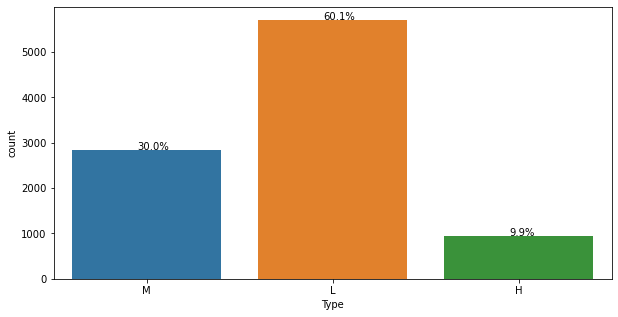

```python
for feature in discrete_feature:
    plt.figure(figsize=(10,5))
    plot=sns.countplot(df[feature])

    total = len(df[feature])
    for p in plot.patches:
        percentage = '{:.1f}%'.format(100 * p.get_height()/total)
        x = p.get_x() + p.get_width() / 2 - 0.05
        y = p.get_y() + p.get_height()
        plot.annotate(percentage, (x, y), size = 10)

    plt.show()
```

The dataset has 60% of low type product.

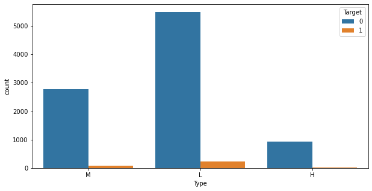

```python
for i in discrete_feature:
        plt.figure(figsize=(10,5))
        sns.countplot(df[i],hue=df['Target'])
        plt.show()
```

#### Numerical features

```python
continuous_feature = [feature for feature in df.columns if df[feature].dtypes != 'O' and feature not in discrete_feature+['Target']]

print("Number of numerical features: ", len(continuous_feature))
```

```
Number of numerical features:  5
```

```python
continuous_feature
```

```
['Air_temperature',
 'Process_temperature',
 'Rotational_speed',
 'Torque',
 'Tool_wear']
```

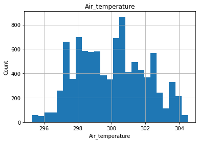

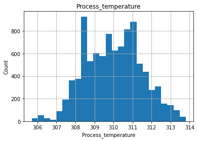

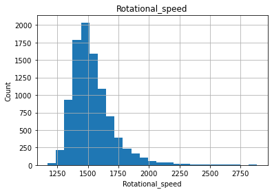

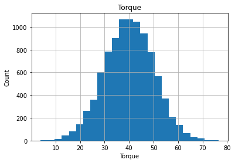

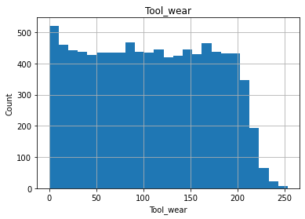

```python
for feature in continuous_feature:
    data=df.copy()
    data[feature].hist(bins=25)
    plt.xlabel(feature)
    plt.ylabel("Count")
    plt.title(feature)
    plt.show()
```

Some of the features are skewed.

```python
from scipy.stats import shapiro

for feature in continuous_feature:
    data = df.copy()
    DataToTest = data[feature]
    stat, p = shapiro(DataToTest)
    print(feature)
    print('stat = %.2f, p = %.30f' % (stat, p))

    if p > 0.05:
        print('Normal distribution')
        print()
    else:
        print('Not a normal distribution')
        print()
```

```
Air_temperature
stat = 0.98, p = 0.000000000000000000000000000000
Not a normal distribution

Process_temperature
stat = 0.99, p = 0.000000000000000000000243515682
Not a normal distribution

Rotational_speed
stat = 0.86, p = 0.000000000000000000000000000000
Not a normal distribution

Torque
stat = 1.00, p = 0.539811491966247558593750000000
Normal distribution

Tool_wear
stat = 0.96, p = 0.000000000000000000000000000000
Not a normal distribution
```

- Except Torque all other features are not normally distributed.
- Let us apply log transformation for the skewed features.

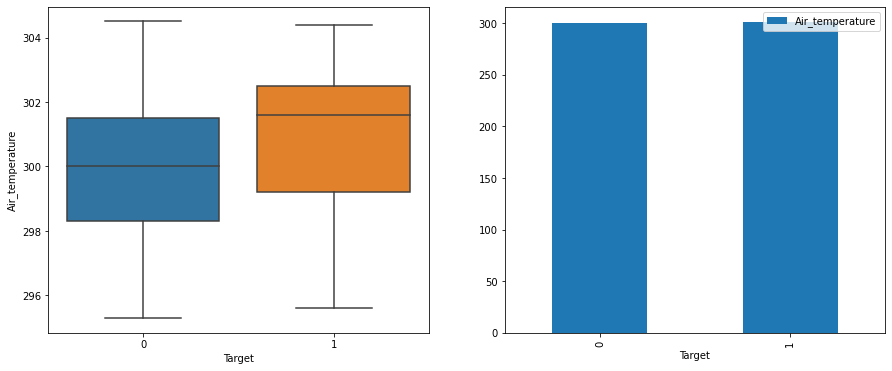

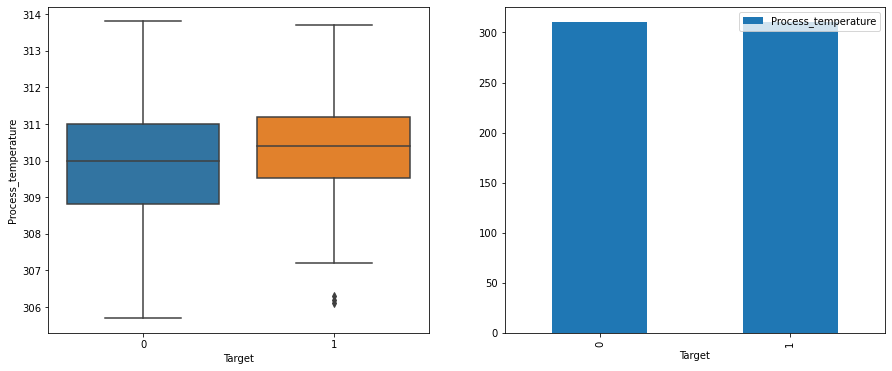

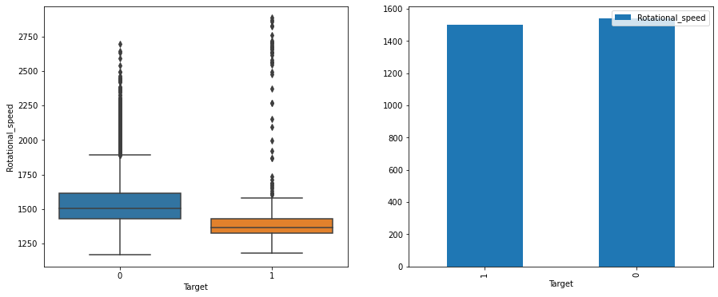

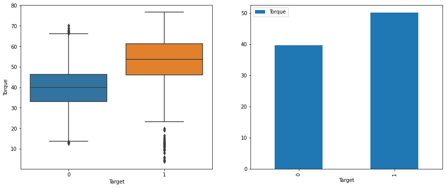

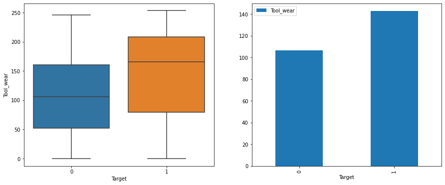

```python
for i in continuous_feature:
    f,axes=plt.subplots(1,2,figsize=(15,6))
    sns.boxplot(x='Target', y=i, data= df, ax=axes[0])
    df.groupby(by=['Target'])[i].mean().reset_index().sort_values(i,ascending=True).plot(x='Target',y=i,kind='bar',ax=axes[1])
```

#### Checking for outliers

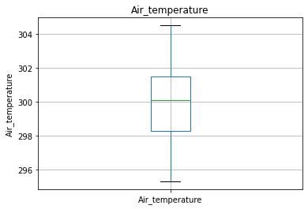

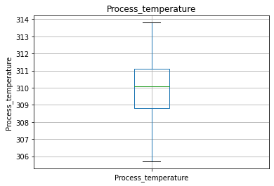

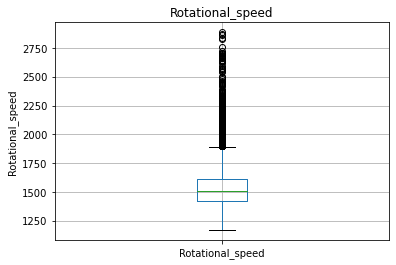

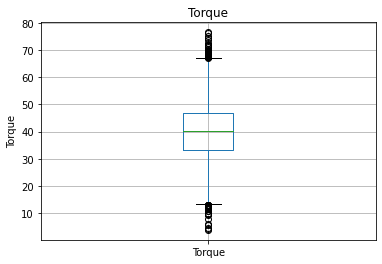

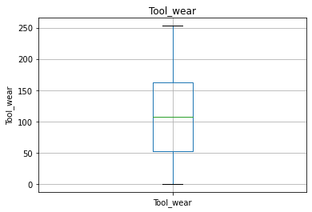

```python
for feature in continuous_feature:

    data = df.copy()
    data.boxplot(column=feature)
    plt.ylabel(feature)
    plt.title(feature)
    plt.show()
```

- Rotational_speed and Torque have outliers in them.
- We will be using machine learning models that are robust to outliers

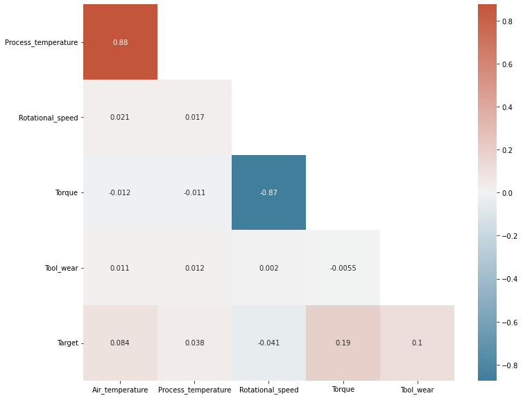

```python
corr = df.corr()
f, ax = plt.subplots(figsize=(12, 10))
mask = np.triu(np.ones_like(corr, dtype=bool))[1:, :-1]
corr = corr.iloc[1:,:-1].copy()
cmap = sns.diverging_palette(230, 20, as_cmap=True)
sns.heatmap(corr, annot=True, mask = mask, cmap=cmap)
plt.yticks(rotation=0)
plt.show()
```

*OBSERVATIONS*

- Process_temperature and Air_temperature are highly positively correlated
- Torque and Rotational_speed are highly negatively correlated.

In Feature Selection we will check whether these features are really required for predicting the Target.

## FEATURE ENGINEERING

```python
X_train_final, X_validation, y_train_final, y_validation = train_test_split(X_train, y_train,  random_state = RS, test_size = 0.20, stratify = y_train)
# X_train_final.sort_index(axis = 0, inplace = True)
# X_validation.sort_index(axis = 0, inplace = True)
# y_train_final.sort_index(axis = 0, inplace = True)
# y_validation.sort_index(axis = 0, inplace = True)
```

```python
X_train_final_1 = X_train_final.copy()
X_validation_1 = X_validation.copy()
y_train_final_1 = y_train_final.copy()
y_validation_1 = y_validation.copy()
```

```python
from sklearn.preprocessing import OrdinalEncoder

ord = ['L', 'M', 'H']
ordinal_encoder = OrdinalEncoder(categories = [ord])
X_train_final_1['Type'] = ordinal_encoder.fit_transform(X_train_final_1[['Type']])
X_validation_1['Type'] = ordinal_encoder.transform(X_validation_1[['Type']])
```

```python
ordinal_encoder.categories_
```

```
[array(['L', 'M', 'H'], dtype=object)]
```

#### Applying Log Transformations

```python
from sklearn.preprocessing import FunctionTransformer

to_transform = ['Air_temperature', 'Process_temperature', 'Rotational_speed', 'Tool_wear']

transformer = FunctionTransformer(np.log1p)
X_train_final_1[to_transform] = transformer.fit_transform(X_train_final_1[to_transform])
X_validation_1[to_transform] = transformer.transform(X_validation_1[to_transform])
```

#### Scaling the dataset

```python
from sklearn.preprocessing import StandardScaler

to_scale = ['Air_temperature', 'Process_temperature', 'Rotational_speed', 'Torque', 'Tool_wear']

scaler = StandardScaler()
X_train_final_1[to_scale] = scaler.fit_transform(X_train_final_1[to_scale])
X_validation_1[to_scale] = scaler.transform(X_validation_1[to_scale])
```

```python
X_train_final_1.head()
```

|  | Type | Air_temperature | Process_temperature | Rotational_speed | Torque | Tool_wear |
| --- | --- | --- | --- | --- | --- | --- |
| 1147 | 1.0 | -1.462450 | -1.361179 | 0.935560 | -1.451484 | 0.696741 |
| 8831 | 2.0 | -1.310989 | -0.885450 | 1.131691 | -1.330773 | 0.690436 |
| 5936 | 1.0 | 0.245252 | 0.265429 | 0.118935 | -0.274550 | -0.193807 |
| 7866 | 0.0 | 0.245252 | 1.275705 | -0.612284 | 0.942621 | -0.749010 |
| 6480 | 0.0 | 0.345104 | -0.072411 | 1.392178 | -1.350892 | 0.631836 |

## FEATURE SELECTION

*Checking for constant, quasi constant features*

```python
from sklearn.feature_selection import VarianceThreshold

constant_filter = VarianceThreshold(threshold = 0.01)
constant_filter.fit(X_train_final_1)
```

```
VarianceThreshold(threshold=0.01)
```

```python
constant_filter.get_support().sum()
```

```
6
```

There are no constant and quasi constant features in the dataset.

*Checking for duplicate features*

```python
X_train_T = X_train_final_1.T
X_train_T.duplicated().sum()
```

```
0
```

There are no duplicate features in the dataset

*Checking for multicollinearity*

```
<BarContainer object of 7 artists>
```

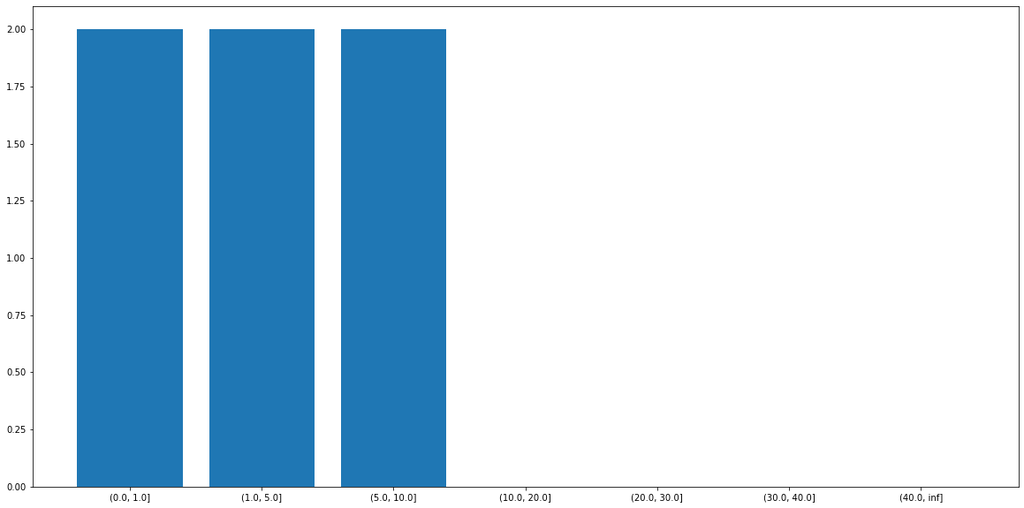

```python
df = X_train_final_1.copy()
vif = pd.Series(np.linalg.inv(df.corr().values).diagonal(),index=df.columns,
          name='VIF').abs().sort_values(ascending=False).round(2)
df = pd.cut(vif.round(1),[0,1,5,10,20,30,40,float('inf')]).value_counts().sort_index()
df.index = df.index.map(str)

plt.subplots(figsize=(20, 10))
plt.bar(x=df.index, height=df)
```

- Generally VIF > 10 is considered as high, None of the features have VIF value greater than 10.

*Feature selection by Recursive Feature Elimination*

```python
from sklearn.model_selection import StratifiedKFold
from sklearn.feature_selection import RFECV

skf = StratifiedKFold(n_splits=5, random_state = RS, shuffle=True)
sel = RFECV(RandomForestClassifier(n_estimators = 100, random_state = RS, n_jobs = -1), cv = skf)
sel.fit(X_train_final_1, y_train_final_1)
sel.get_support()
```

```
array([False,  True,  True,  True,  True,  True])
```

```python
features = X_train_final_1.columns[sel.get_support()]
features
```

```
Index(['Air_temperature', 'Process_temperature', 'Rotational_speed', 'Torque',
       'Tool_wear'],
      dtype='object')
```

```python
X_train_sel = pd.DataFrame(sel.transform(X_train_final_1), columns = features)
X_train_sel.shape, y_train_final_1.shape
```

```
((7600, 5), (7600,))
```

### SMOTE

```python
y_train_final_1.value_counts()
```

```
0    7342
1     258
Name: Target, dtype: int64
```

```python
from imblearn.over_sampling import SMOTE
oversample = SMOTE(random_state = RS)
X_train_upsampled, y_train_upsampled = oversample.fit_resample(X_train_sel, y_train_final_1)
```

```python
y_train_upsampled.value_counts()
```

```
0    7342
1    7342
Name: Target, dtype: int64
```

```python
X_train_upsampled.shape, y_train_upsampled.shape
```

```
((14684, 5), (14684,))
```

```python
X_validation_sel = pd.DataFrame(sel.transform(X_validation_1), columns = features)
X_validation_sel.shape, y_validation_1.shape
```

```
((1900, 5), (1900,))
```

## MODEL BUILDING

```python
from sklearn import metrics

scorer = {
    'accuracy' : metrics.make_scorer(metrics.accuracy_score),
    'precision' : metrics.make_scorer(metrics.precision_score),
    'recall' : metrics.make_scorer(metrics.recall_score),
    'f1' : metrics.make_scorer(metrics.f1_score),
    'loss' : metrics.make_scorer(metrics.log_loss)
}
```

```python
import time
```

```python
def fit_models(model, X_train, X_test, y_train, y_test):

    start = time.time()

    model.fit(X_train, y_train)
    pred = model.predict(X_test)

    accuracy = metrics.accuracy_score(y_test,pred)
    precision = metrics.precision_score(y_test,pred)
    recall = metrics.recall_score(y_test,pred)
    f1 = metrics.f1_score(y_test,pred)
    loss = metrics.log_loss(y_test,pred)

    scorer = {
    'accuracy' : metrics.make_scorer(metrics.accuracy_score),
    'precision' : metrics.make_scorer(metrics.precision_score),
    'recall' : metrics.make_scorer(metrics.recall_score),
    'f1' : metrics.make_scorer(metrics.f1_score),
    'loss' : metrics.make_scorer(metrics.log_loss)
    }

    cv = cross_validate(estimator = model, X = X_train, y = y_train, cv=10, scoring = scorer)

    accuracy_cv = cv['test_accuracy'].mean()
    precision_cv = cv['test_precision'].mean()
    recall_cv = cv['test_recall'].mean()
    f1_cv = cv['test_f1'].mean()
    loss_cv = cv['test_loss'].mean()

    end = time.time()  #note the end time
    duration = end - start  # calculate the total duration

    return f1, accuracy, precision, recall, loss, f1_cv, accuracy_cv, precision_cv, recall_cv, loss_cv, duration
```

```python
lr = LogisticRegression(random_state = RS)
gnb = GaussianNB()
knn = KNeighborsClassifier()
svm = SVC(random_state = RS)
dT_gini = DecisionTreeClassifier(random_state = RS)
dT_entropy = DecisionTreeClassifier(random_state = RS)
bgcl = BaggingClassifier(n_estimators=100,random_state = RS)
abcl = AdaBoostClassifier(n_estimators=100, random_state = RS)
gbcl = GradientBoostingClassifier(n_estimators = 100,random_state = RS)
rfcl = RandomForestClassifier(n_estimators = 100, random_state = RS)
xgbcl = XGBClassifier(n_estimators = 100, random_state = RS, eval_metric = 'logloss')

result = {}

for model,name in zip([lr, gnb, knn, svm, dT_gini, dT_entropy, bgcl, abcl, gbcl, rfcl, xgbcl],
                     ['Logistic Regression', 'Gaussian NB', 'KNN', 'SVC', 'Decision Tree(gini)',
                     'Decision Tree(entropy)', 'Bagging Classifier', 'Adaptive Boosting',
                      'Gradient Boosting', 'Random Forest Classifier', 'XGB Classifier']):
    result[name] = fit_models(model,X_train_upsampled, X_validation_sel, y_train_upsampled, y_validation_1)
```

```python
result1 = pd.DataFrame(np.array(list(result.values())),    # make a dataframe out of the metrics from result dictionary
                       columns= ['F1-SCORE', 'ACCURACY', 'PRECISION', 'RECALL', 'LOG LOSS', 'F1_SCORE(CV)', 'ACCURACY(CV)',
                                'PRECISION(CV)', 'RECALL(CV)',  'LOG LOSS(CV)', 'DURATION'],
                       index= result.keys())   # use the model names as index

result1.index.name = 'Model'   # name the index of the result1 dataframe as 'Model'

result1
```

| Model | F1-SCORE | ACCURACY | PRECISION | RECALL | LOG LOSS | F1_SCORE(CV) | ACCURACY(CV) | PRECISION(CV) | RECALL(CV) | LOG LOSS(CV) | DURATION |
| --- | --- | --- | --- | --- | --- | --- | --- | --- | --- | --- | --- |
| Logistic Regression | 0.198312 | 0.800000 | 0.114634 | 0.734375 | 6.907908 | 0.794936 | 0.794607 | 0.793797 | 0.796380 | 7.094103 | 0.222435 |
| Gaussian NB | 0.222222 | 0.819474 | 0.129973 | 0.765625 | 6.235296 | 0.807237 | 0.807750 | 0.809471 | 0.805227 | 6.640167 | 0.093966 |
| KNN | 0.374468 | 0.922632 | 0.257310 | 0.687500 | 2.672264 | 0.960782 | 0.959480 | 0.931426 | 0.992101 | 1.399533 | 0.625015 |
| SVC | 0.401544 | 0.918421 | 0.266667 | 0.812500 | 2.817697 | 0.935036 | 0.933601 | 0.915279 | 0.955732 | 2.293387 | 27.082169 |
| Decision Tree(gini) | 0.564706 | 0.961053 | 0.452830 | 0.750000 | 1.345219 | 0.971709 | 0.971671 | 0.968932 | 0.974665 | 0.978478 | 0.516133 |
| Decision Tree(entropy) | 0.564706 | 0.961053 | 0.452830 | 0.750000 | 1.345219 | 0.971709 | 0.971671 | 0.968932 | 0.974665 | 0.978478 | 0.499841 |
| Bagging Classifier | 0.593548 | 0.966842 | 0.505495 | 0.718750 | 1.145252 | 0.980403 | 0.980319 | 0.976136 | 0.984745 | 0.679759 | 28.543887 |
| Adaptive Boosting | 0.444444 | 0.931579 | 0.305882 | 0.812500 | 2.363229 | 0.928197 | 0.927541 | 0.920160 | 0.936529 | 2.502664 | 8.502531 |
| Gradient Boosting | 0.492891 | 0.943684 | 0.353741 | 0.812500 | 1.945118 | 0.952646 | 0.951853 | 0.937570 | 0.968265 | 1.662964 | 16.416760 |
| Random Forest Classifier | 0.584416 | 0.966316 | 0.500000 | 0.703125 | 1.163430 | 0.981782 | 0.981681 | 0.976709 | 0.986925 | 0.632737 | 14.860924 |
| XGB Classifier | 0.657718 | 0.973158 | 0.576471 | 0.765625 | 0.927109 | 0.985547 | 0.985495 | 0.981372 | 0.989785 | 0.500991 | 4.907114 |

XGB Classifier and Random forest classifiers outperforms the other models. we have to choose one between them.

### Model evaluation function

```python
from sklearn.metrics import precision_recall_curve
from sklearn.metrics import f1_score
from sklearn.metrics import auc
from sklearn.metrics import log_loss
from sklearn.metrics import precision_recall_curve, roc_auc_score, auc, roc_curve

def evaluation(clf, X, y):
    pred = clf.predict(X)
    y_predict_proba = clf.predict_proba(X)[:, 1]

    precision, recall, thresholds = precision_recall_curve(y, y_predict_proba)
    fpr, tpr, thresholds = roc_curve(y, y_predict_proba)
    f1 = f1_score(y, pred)
    loss = log_loss(y, pred)

    return{
        'ROC AUC': auc(fpr, tpr), # Alternatively: roc_auc_score(y, y_predict_proba)
        'PRECISION-RECALL AUC': auc(recall, precision), # Alternatively (with slight difference): average_precision_score(y, y_predict_proba)
        'F1-SCORE': f1,
        'LOSS': loss
    }
```

## RANDOM FOREST CLASSIFIER

```python
rfcl.score(X_train_upsampled, y_train_upsampled)
```

```
1.0
```

*Hyperparameter tuning*

```python
params={'bootstrap': [True, False],
        'max_depth': [10, 20, 30, 40, 50, 60, 70, 80, 90, 100, None],
        'max_features': ['auto', 'sqrt'],
        'min_samples_leaf': [1, 2, 4],
        'min_samples_split': [2, 5, 10],
        'n_estimators': [200, 400, 600, 800, 1000]}
```

```python
ran_clf_hp = RandomForestClassifier()

grd_rfc = RandomizedSearchCV(estimator = ran_clf_hp, param_distributions = params, n_iter = 100, cv=skf, n_jobs = -1)
grd_rfc.fit(X_train_upsampled, y_train_upsampled)
```

```
RandomizedSearchCV(cv=StratifiedKFold(n_splits=5, random_state=42, shuffle=True),
                   estimator=RandomForestClassifier(), n_iter=100, n_jobs=-1,
                   param_distributions={'bootstrap': [True, False],
                                        'max_depth': [10, 20, 30, 40, 50, 60,
                                                      70, 80, 90, 100, None],
                                        'max_features': ['auto', 'sqrt'],
                                        'min_samples_leaf': [1, 2, 4],
                                        'min_samples_split': [2, 5, 10],
                                        'n_estimators': [200, 400, 600, 800,
                                                         1000]})
```

```python
grd_rfc.best_params_
```

```
{'n_estimators': 1000,
 'min_samples_split': 2,
 'min_samples_leaf': 1,
 'max_features': 'sqrt',
 'max_depth': 20,
 'bootstrap': False}
```

```python
ran_clf_hp = RandomForestClassifier(**grd_rfc.best_params_)
ran_clf_hp.fit(X_train_upsampled, y_train_upsampled)
```

```
RandomForestClassifier(bootstrap=False, max_depth=20, max_features='sqrt',
                       n_estimators=1000)
```

### PREDICTION ON VALIDATION DATA AFTER HPT

```python
pred = ran_clf_hp.predict(X_validation_sel)
report = pd.DataFrame(classification_report(y_validation_1, pred, output_dict=True)).T
report
```

|  | precision | recall | f1-score | support |
| --- | --- | --- | --- | --- |
| 0 | 0.989029 | 0.982026 | 0.985515 | 1836.000000 |
| 1 | 0.571429 | 0.687500 | 0.624113 | 64.000000 |
| accuracy | 0.972105 | 0.972105 | 0.972105 | 0.972105 |
| macro avg | 0.780229 | 0.834763 | 0.804814 | 1900.000000 |
| weighted avg | 0.974963 | 0.972105 | 0.973342 | 1900.000000 |

### Model evaluation

```python
evaluation(ran_clf_hp, X_validation_sel, y_validation_1)
```

```
{'ROC AUC': 0.961835341775599,
 'PRECISION-RECALL AUC': 0.7160547904150014,
 'F1-SCORE': 0.624113475177305,
 'LOSS': 0.9634639661291916}
```

### PREDICTION ON TEST DATA

```python
X_test.shape, y_test.shape
```

```
((500, 6), (500,))
```

```python
X_test_1 = X_test.copy()
y_test_1 = y_test.copy()
```

*Ordinal encoding*

```python
X_test_1['Type'] = ordinal_encoder.transform(X_test_1[['Type']])
```

*Applying Log Transformations*

```python
X_test_1[to_transform] = transformer.transform(X_test_1[to_transform])
```

*Scaling the data*

```python
X_test_1[to_scale] = scaler.transform(X_test_1[to_scale])
```

*Feature selection by Recursive Feature Elimination with cross-validation*

```python
X_test_sel = pd.DataFrame(sel.transform(X_test_1), columns = features)
```

### Prediction made by the vanilla model

```python
pred = rfcl.predict(X_test_sel)
report = pd.DataFrame(classification_report(y_test_1, pred, output_dict=True)).T
report
```

|  | precision | recall | f1-score | support |
| --- | --- | --- | --- | --- |
| 0 | 0.995763 | 0.973085 | 0.984293 | 483.00 |
| 1 | 0.535714 | 0.882353 | 0.666667 | 17.00 |
| accuracy | 0.970000 | 0.970000 | 0.970000 | 0.97 |
| macro avg | 0.765738 | 0.927719 | 0.825480 | 500.00 |
| weighted avg | 0.980121 | 0.970000 | 0.973494 | 500.00 |

### Model evaluation

```python
evaluation(rfcl, X_test_sel, y_test_1)
```

```
{'ROC AUC': 0.938740713676775,
 'PRECISION-RECALL AUC': 0.716201130881889,
 'F1-SCORE': 0.6666666666666667,
 'LOSS': 1.0361840813805063}
```

### Prediction made by hyperparameter tuned model

```python
pred = ran_clf_hp.predict(X_test_sel)
report = pd.DataFrame(classification_report(y_test_1, pred, output_dict=True)).T
report
```

|  | precision | recall | f1-score | support |
| --- | --- | --- | --- | --- |
| 0 | 0.995772 | 0.975155 | 0.985356 | 483.000 |
| 1 | 0.555556 | 0.882353 | 0.681818 | 17.000 |
| accuracy | 0.972000 | 0.972000 | 0.972000 | 0.972 |
| macro avg | 0.775664 | 0.928754 | 0.833587 | 500.000 |
| weighted avg | 0.980804 | 0.972000 | 0.975035 | 500.000 |

### Model evaluation

```python
evaluation(ran_clf_hp, X_test_sel, y_test_1)
```

```
{'ROC AUC': 0.9615150407989282,
 'PRECISION-RECALL AUC': 0.6943608892965675,
 'F1-SCORE': 0.6818181818181819,
 'LOSS': 0.9671049293958246}
```

- We can see that Hyperparameter tuning does really help our model to learn more.

## RANDOM FOREST CLASSIFIER - PIPELINE

```python
from sklearn.compose import ColumnTransformer
from sklearn.pipeline import Pipeline

my_cols = ['Air_temperature', 'Process_temperature', 'Rotational_speed', 'Torque', 'Tool_wear']

cols_to_order = Pipeline(steps=[
    ('ordinal', OrdinalEncoder(categories = [ord]))
])

cols_to_log_transform = Pipeline(steps=[
    ('log_transform', FunctionTransformer(np.log1p))
])

cols_to_scale_transform = Pipeline(steps=[
    ('scaler', StandardScaler())
])

preprocessor = ColumnTransformer(transformers = [
    ('selector', 'passthrough', my_cols),
    ('ordinal_cols', cols_to_order, discrete_feature),
    ('skewed_cols', cols_to_log_transform, to_transform),
    ('cols_to_scale', cols_to_scale_transform, to_scale)
], remainder = 'drop')
```

```python
from imblearn.pipeline import make_pipeline

clf = make_pipeline(preprocessor,
                    SMOTE(random_state = 42),
                    RandomForestClassifier())

params=[
        {'randomforestclassifier': [RandomForestClassifier()],
          'randomforestclassifier__bootstrap': [True, False],
          'randomforestclassifier__max_depth': [10, 20, 30, 40, 50, 60, 70, 80, 90, 100, None],
          'randomforestclassifier__max_features': ['auto', 'sqrt'],
          'randomforestclassifier__min_samples_leaf': [1, 2, 4],
          'randomforestclassifier__min_samples_split': [2, 5, 10],
          'randomforestclassifier__n_estimators': [200, 400, 600, 800, 1000]
        }]

ran_search = RandomizedSearchCV(estimator = clf, param_distributions = params, n_iter = 100, cv = skf, random_state=RS, n_jobs = -1)
best_model = ran_search.fit(X_train, y_train)
```

```python
best_model.best_params_
```

```
{'randomforestclassifier__n_estimators': 600,
 'randomforestclassifier__min_samples_split': 2,
 'randomforestclassifier__min_samples_leaf': 1,
 'randomforestclassifier__max_features': 'auto',
 'randomforestclassifier__max_depth': 50,
 'randomforestclassifier__bootstrap': False,
 'randomforestclassifier': RandomForestClassifier(bootstrap=False, max_depth=50, n_estimators=600)}
```

### Prediction made by hyperparameter tuned model(PIPELINE) on test data

```python
pred = best_model.predict(X_test)
report = pd.DataFrame(classification_report(y_test, pred, output_dict=True)).T
report
```

|  | precision | recall | f1-score | support |
| --- | --- | --- | --- | --- |
| 0 | 0.993671 | 0.975155 | 0.984326 | 483.00 |
| 1 | 0.538462 | 0.823529 | 0.651163 | 17.00 |
| accuracy | 0.970000 | 0.970000 | 0.970000 | 0.97 |
| macro avg | 0.766066 | 0.899342 | 0.817744 | 500.00 |
| weighted avg | 0.978194 | 0.970000 | 0.972998 | 500.00 |

### Model evaluation

```python
evaluation(best_model, X_test, y_test)
```

```
{'ROC AUC': 0.9567653148215809,
 'PRECISION-RECALL AUC': 0.7462612900807448,
 'F1-SCORE': 0.6511627906976744,
 'LOSS': 1.0361824821856458}
```

## TRAINING OUR MODEL ON ENTIRE DATASET WITH THE CHOSEN MODEL AND HYPERPARAMETERS

```python
prod_clf = make_pipeline(preprocessor,
                    SMOTE(random_state = 42),
                    best_model.best_params_['randomforestclassifier'])

prod_model = prod_clf.fit(X,Y)
```

```python
all_accuracies = cross_validate(estimator=prod_model, X = X, y = Y, cv=10, scoring = scorer, n_jobs = -1)
```

```python
all_accuracies
```

```
{'fit_time': array([39.78132701, 38.86623168, 38.219944  , 38.29452443, 38.80640364,
        38.55147338, 39.48212123, 38.52188945, 38.96796274, 39.15131092]),
 'score_time': array([0.09370804, 0.12595677, 0.17229748, 0.18881536, 0.12496996,
        0.14059091, 0.09539557, 0.15621185, 0.10939145, 0.10929346]),
 'test_accuracy': array([0.97 , 0.967, 0.939, 0.936, 0.95 , 0.946, 0.933, 0.954, 0.967,
        0.978]),
 'test_precision': array([0.55555556, 0.51111111, 0.30434783, 0.33695652, 0.39473684,
        0.38095238, 0.18867925, 0.36363636, 0.51724138, 0.73076923]),
 'test_recall': array([0.45454545, 0.67647059, 0.61764706, 0.91176471, 0.88235294,
        0.94117647, 0.29411765, 0.47058824, 0.44117647, 0.55882353]),
 'test_f1': array([0.5       , 0.58227848, 0.40776699, 0.49206349, 0.54545455,
        0.54237288, 0.22988506, 0.41025641, 0.47619048, 0.63333333]),
 'test_loss': array([1.03617289, 1.13979721, 2.10690374, 2.21053046, 1.7269756 ,
        1.8651355 , 2.3141324 , 1.5888061 , 1.13979082, 0.75985868])}
```

## CHECKING WHETHER CV TEST ACCURACY IS NORMALLY DISTRIBUTED

```python
DataToTest = all_accuracies['test_accuracy']
stat, p = shapiro(DataToTest)
print('stat = %.2f, p = %.30f' % (stat, p))

if p > 0.05:
    print('Normal distribution')
    print()
else:
    print('Not a normal distribution')
    print()
```

```
stat = 0.93, p = 0.489526540040969848632812500000
Normal distribution
```

## AVERAGE ACCURACY

```python
avg_score = all_accuracies['test_accuracy'].mean()
std = all_accuracies['test_accuracy'].std()
std_2 = std * 2
production_acc_min = avg_score - std_2
production_acc_max = avg_score + std_2
print("Average cv score: ", avg_score)
print("Standard deviation: ", std)
print("Accuracy of our model will range from {} to {} (WITH 95% CONFIDENCE-Emprical Rule) ".format(production_acc_min, production_acc_max))
```

```
Average cv score:  0.954
Standard deviation:  0.01496662954709575
Accuracy of our model will range from 0.9240667409058084 to 0.9839332590941915 (WITH 95% CONFIDENCE-Emprical Rule)
```

```python
import pickle
filename = 'machine_predictive_maintenance(random_forest).sav'
pickle.dump(prod_model, open(filename, 'wb'))
```